# Explainer Notebook

Kasper Brun (s204599)

# With subtle notes of dry summer rain

### What does wine taste like?

### Data

Truth be told there is no official Vivino API documentation, and the data has been collected through an amalgamation of different scraps found on the internet combined through patience and trial-and-error. For the first step I collected the *wines data set* consisting of 5 216 unique wine ids with description, year, ratings, price, type (red, wine, etc.) and more. Price, wine ID, and year were all needed for API requests, so there may have been lost some wines due to this. (Note: Not all wines had an actual year but a tag of "N.V." (no value, presumably) and are still included)

#### API REQUESTS - WINES

```python
WINE_ID_LIST = []
WINE_YEAR_LIST = []

#Requesting wine IDs. Searching through the pages for the different types of wines.
def requester(PAGE,TYPE):
    r = requests.get(
        "https://www.vivino.com/api/explore/explore?lang=en",
        params={
            "currency_code": "EUR",
            "order_by": "price",
            "order": "asc",
            "page": PAGE,
            "price_range_min": "0",
            "wine_type_ids[]": TYPE,
        },
        #Doesnt work without this. I dont dare to mess with it.
        headers={
            "User-Agent": "Mozilla/5.0 (Windows NT 10.0; Win64; x64; rv:66.0) Gecko/20100101 Firefox/66.0"
        },
    )

    #Creating tuple for results
    results = [(
            t["vintage"]["wine"]["winery"]["name"],
            t["vintage"]["year"],
            t["vintage"]["wine"]["id"],
            TYPE, #Type is always the same anyway
            f'{t["vintage"]["wine"]["name"]} {t["vintage"]["year"]}',
            t["vintage"]["statistics"]["ratings_average"],
            t["vintage"]["statistics"]["ratings_count"],
            t["price"]["amount"]
            )
            for t in r.json()["explore_vintage"]["matches"]
    ]
    #None values are present in description. Not a pretty solution. Is what it is.
    DESC_LIST = []
    for t in r.json()["explore_vintage"]["matches"]:
        if t["vintage"]["wine"]["style"] == None:
            DESC_LIST.append(None)
        else:
            DESC_LIST.append(t["vintage"]["wine"]["style"]["description"])
    #Countries prove problematic aswell...
    COUNTRY_LIST = []
    for t in r.json()["explore_vintage"]["matches"]:
        if t['vintage']['wine']["region"] == None:
            COUNTRY_LIST.append(None)
        else:
            COUNTRY_LIST.append(t['vintage']['wine']["region"]["country"]["seo_name"])

    #New tuple creation
    results = [results[i]+(COUNTRY_LIST[i],)+(DESC_LIST[i],) for i in range(len(results))]
    return results

#Wine type IDs
#1: Red
#2: White
#3: Sparkling
#4: Rosé

COLUMNS = ["Winery", "Year", "Wine ID","Type", "Wine","Rating", "num_review", "Price","Country","Description"]

#Creating initial dataframe
r = requester(0,1)
df_wines = pd.DataFrame(r,
    columns=COLUMNS)

#Requesting all the wines and concatenating to dataframe
for PAGE in (range(0,90)): #Through all relevant pages
    for TYPE in range(1,5): #Through the 4 different types
        r = requester(PAGE,TYPE)
        df2 = pd.DataFrame(r,
        columns=COLUMNS)
        df_wines = pd.concat([df_wines,df2]).drop_duplicates(subset="Wine ID").reset_index(drop=True)
        #Printer to follow the results.
        print(f"Iteration {PAGE}. DataFrame length {len(df_wines)}. Number of wines", len(set(df_wines["Wine ID"])))
```

###### Relevant Attributes for the WInes Dataset

```
Winery
Price
Rating
Country
Description
```

Next step was to collect the reviews (called 'Notes' in the API). However, I could not get the API to only fetch a particular language which resulted in 4 446 322 reviews along with their respective rating (1-5), date, and various user statistics as purchases (through Vivino.com presumably), followers, followings, and comments_count. Also, *exactly* what I managed to gather is unclear. Somehow, I have more reviews for some wines in my *reviews data set* than the wines dataset suggests, but at the same time I cannot seem to find one of my friend's catch phrase he always writes in his reviews. I suspect not all reviews are featured on the website, thus ignoring reviews in the app, but on the other hand 4.4m reviews seem a lot for only computer based reviews. Furthermore, since I only request the website, and given most wines are from recent years, it could indicate only wines currently purchasable on Vivino are requested.

#### API REQUESTS - REVIEWS

```python
#API CALLER FUNCTION
def get_wine_data(wine_id, year, page, price):
    headers = {
        "User-Agent": "Mozilla/5.0 (X11; Ubuntu; Linux x86_64; rv:89.0) Gecko/20100101 Firefox/89.0",
    }

    api_url = "https://www.vivino.com/api/wines/{id}/reviews?per_page=50&year={year}&page={page}&price_id={price}"

    data = requests.get(api_url.format(id=wine_id, year=year, page=page, price=price), headers=headers).json()
    return data

#API CALLS
ratings = []
counter = set({})

#Requesting. REQUEST_DF is just the wine dataframe.
#I had to do it over multiple rounds - the REQUEST_DF filtered already requested wines.
for _, row in REQUEST_DF.iterrows():
    #Looping through all the pages.
    page = 1
    while True:
        ratings = []
        counter.add(row["Wine ID"])
        print(f'Getting info about wine {row["Wine ID"]}-{row["Year"]}. Page {page}. Amount of wines: {len(counter)}')

        #Bunch of exceptions to break the loop if they are not present.
        try:
            d = get_wine_data(row["Wine ID"], row["Year"], page, row["Price"])
        except json.JSONDecodeError as e:
            print(f"Error: {e}")
            break

        if "reviews" not in d.keys():
            print("No review")
            break

        if not d["reviews"]:
            break

        for r in d["reviews"]:
            req = [
                row["Year"],
                row["Wine ID"],
                r["user"]["id"],
                r["user"]["alias"],
                r["user"]["language"],
                r["rating"],
                r["note"],
                r["created_at"],
                row["Price"]]

            #Bunch of statistics about the user. May come in handy.
            #Not all users have statistics and activity apparently
            if "statistics" in r["user"].keys():
                req += [r["user"]["statistics"]["purchase_order_count"],
                        r["user"]["statistics"]["followers_count"],
                        r["user"]["statistics"]["followings_count"],
                        r["user"]["is_featured"]]
            else:
                req+=[None,None,None,None]
            if "activity" in r.keys():
                req+=[r["activity"]['statistics']["likes_count"],
                        r["activity"]['statistics']["comments_count"]]
            else:
                req+=[None,None]

            ratings.append(req)
        page += 1

        #Create dataframe if not already created
        if "df_reviews" not in locals().keys():
            df_reviews = pd.DataFrame(ratings, columns=["Year", "Wine ID", "User ID","Alias","Language","User Rating", "Note", "CreatedAt","Price","Total User Purchases",
                                 "followers_count","followings_count","is_featured","likes_count","comments_count"])
        #else concatenate
        else:
            df2 = pd.DataFrame(ratings, columns=["Year", "Wine ID", "User ID","Alias","Language","User Rating", "Note", "CreatedAt","Price","Total User Purchases",
                                 "followers_count","followings_count","is_featured","likes_count","comments_count"])
            df_reviews = pd.concat([df_reviews,df2]).reset_index(drop=True)
```

###### Relevant Attributes for the Review Dataset

```
Created at (date of review)
Note (review)
User ID
User Rating
```

```python
# Remove reviews with Korean, Danish, Chinese, and Russian letters/signs. " y " (Spanish " and ") is also removed.
pattern = r'[가-힣] | y |[æøå]|[\u4e00-\u9fff]+|[а-яА-Я]+'
df_reviews = df_reviews[~df_reviews['Note'].str.contains(pattern)].reset_index(drop=True)

def remove_emojis(text):
    emoji_pattern = re.compile("["
        u"\U0001F600-\U0001F64F"  # emoticons
        u"\U0001F300-\U0001F5FF"  # symbols & pictographs
        u"\U0001F680-\U0001F6FF"  # transport & map symbols
        u"\U0001F1E0-\U0001F1FF"  # flags (iOS)
        u"\U00002702-\U000027B0"
        u"\U000024C2-\U0001F251"
        u"\U0001F900-\U0001F9FF"  # new emojis
        u"\U0001F700-\U0001F77F"  # alchemical symbols
        u"\U0001F780-\U0001F7FF"  # Geometric Shapes Extended
        u"\U0001F800-\U0001F8FF"  # Supplemental Arrows-C
        u"\U0001FA00-\U0001FA6F"  # Chess Symbols
        u"\U0001FA70-\U0001FAFF"  # Symbols and Pictographs Extended-A
        "]+", flags=re.UNICODE)
    return emoji_pattern.sub(r'', text)

df_reviews["Note"] = df_reviews.apply(lambda x: remove_emojis(x.Note),axis=1)
df_reviews = df_reviews.dropna()

def tokenization(TEXT):
    stop_words = set(stopwords.words('english')) # create a set of English stop words
    punctuations = set(string.punctuation) # create a set of punctuation marks

    TEXT = str(TEXT)

    # Tokenize the text
    tokens = word_tokenize(TEXT)

    # Remove stop words and punctuation marks from the token list, exclude URLs, and convert to lowercase
    cleaned_tokens = [token.lower() for token in tokens if token.lower() not in stop_words and token not in punctuations and not re.match(r'http\S+', token)]

    cleaned_text = " ".join(cleaned_tokens)

    return cleaned_text

df_reviews["Token"] = df_reviews.apply(lambda x: tokenization(x.Note), axis=1)
```

The final result are 2 090 072 reviews with some non-English languages left that I cannot get rid of. Trying to filter with NTLK's language detection was no help - it seems to highly prioritize anything being arabic or hindi. Reversely, by filtering with Vivino's language tag some English reviews might also have been lost in translation.

**An observation during the data processing**. Apparently, the data contains many duplicates of the same user id with the same note (i.e. same person writing an identical review) but for different wines. Some of it is just simplistic reviews such as the rating, "nice wine", and "dry". Others treat the reviews as personal notes marking the wine with the occasion (wine tasting?), others again for promotion for their various social media such as TikTok and Instagram. The exact reason is unknown. One could speculate if the different wineries hire bots to upvote their wine, or if Vivino simply has a "quick" review function with basic formula reviews people can easily click to boost interaction numbers. Purely speculative, naturally.

**New Data Set and Variables**  
To create a Network of users a third data set, *users data set*, is generated through the use of pandas groupby function. Statistics regarding the reviewed wine are averaged. The user statistics remaind unchanged and four new variables are created: *Wine ID List*, *reviews*, *prefered type*, and *prefered country*. Former is merely the list of all the wines that the user has reviewed. Reviews is the length of forementioned Wine ID-list. The latter was created through a cross referencing by dictionaries between the Wine ID-list and the countries of the wines data set. Country with most reviewed wines by the user is set as their prefered country, and if there are two countries with equal amount of reviews it is "2+". In a similar manner *prefered type* was created, where equal amount of reviews by wine type will also result in a "2+".

```python
df_w = pd.read_excel("WINES_DF.xlsx")
df_w = df_w.drop(["Unnamed: 0"],axis=1)
df_w["Year"] = df_w["Year"].fillna('N.V.')

## User df

#List of wines reviewed and how many
df_u = df_r.groupby("User ID",as_index=False).mean()
df_u["Wine ID"] = df_r.groupby("User ID").agg({'Wine ID': list}).reset_index()["Wine ID"].to_list()
df_u["reviews"] = df_r.groupby("User ID").agg({'Token': list}).reset_index()["Token"]
df_u["n_reviews"] = df_u.apply(lambda x: len(x["Wine ID"]),axis=1)

#Which country do they prefer wines from?
#Wine to country dictionary
df_indexed = df_w.set_index("Wine ID")
dict_w2c = df_indexed["Country"].to_dict()

def prefcountry2(INP):
    #Create dictionary from input
    stats = {}
    for ID in INP:
        #Count occurences of each country
        if dict_w2c[ID] in stats:
            stats[dict_w2c[ID]] += 1
        else:
            stats[dict_w2c[ID]] = 1
    #Sort
    stats = dict(sorted(stats.items(), key=lambda item: item[1], reverse=True))
    keys = list(stats.keys())

    #If there is more than one country.
    if len(keys) > 1:
        #If most is larger than the next largest
        if stats[keys[0]] > stats[keys[1]]:
            return keys[0]
        #if not...
        else:
            return "2+"
    #If only one country
    elif len(keys) == 0:
        return "unknown"
    else:
        return keys[0]

df_u["pref_country"] = df_u.apply(lambda x: prefcountry2(x["Wine ID"]),axis=1)

#Wine to Type-dictionary
df_indexed = df_w.set_index("Wine ID")
dict_w2t = df_indexed["Type"].to_dict()

def preftype(INP):
    #Initialize dictionary
    stats = {}
    for ID in INP:
        if dict_w2t[ID] in stats:
            stats[dict_w2t[ID]] += 1
        else:
            stats[dict_w2t[ID]] = 1
    #Sort
    stats = dict(sorted(stats.items(), key=lambda item: item[1], reverse=True))
    keys = list(stats.keys())

    #If there is more than wine.
    if len(keys) > 1:
        #If most is larger than the next largest
        if stats[keys[0]] > stats[keys[1]]:
            return(keys[0])
        #if not...
        else:
            return("2+")
    #If only one country
    else:
        return(keys[0])

df_u["pref_type"] = df_u.apply(lambda x: preftype(x["Wine ID"]),axis=1)

#Merging statistics for the wine dataframe
df_w["description token"] = df_w.apply(lambda x: tokenization(x.Description),axis=1)
merger = df_r.groupby("Wine ID").mean().reset_index()
merger["Token"] = df_r.groupby("Wine ID").agg({'Token': list}).reset_index()["Token"]
merger["User ID"] = df_r.groupby("Wine ID").agg({'User ID': list}).reset_index()["User ID"]
merger["n_reviews"] = merger.apply(lambda x: len(x.Token),axis=1)
df_w = pd.merge(df_w, merger, on="Wine ID",how="inner")
```

###### Relevant Attributes for the Users Dataset

```
User Rating (mean)
Price (mean)
Total User Purchases (mean)
Comments count (mean)
Followers Count (mean)
Followings Count (mean)
Is Featured (yes (1) or no (0))
Likes Count (mean)
Reviews (mean)
Prefered Country
Prefered Type
```

All the variables may seem odd, but the individual registration (row) holds the value at the time reviews. Thus, over time the different values change and therefore the need for an average.

```python
import pandas as pd
df_w = pd.read_csv("DF_WINES_3.csv",low_memory=False)
df_r = pd.read_csv("DF_TOKENS_REVIEW_2.csv",low_memory=False)
df_u = pd.read_csv("DF_USER_3.csv",low_memory=False)
df_r = df_r.drop("Unnamed: 0",axis=1)
df_w = df_w.drop("Unnamed: 0",axis=1)
```

```python
print("There are", len(set(df_w["Wine ID"])), "unique wines reviewed by", len(set(df_r["User ID"])), "different reviewees"\
     " for a grant total of",len(set(df_r["Note"])),"unique reviews.")
```

```
There are 5216 unique wines reviewed by 766617 different reviewees for a grant total of 1771176 unique reviews.
```

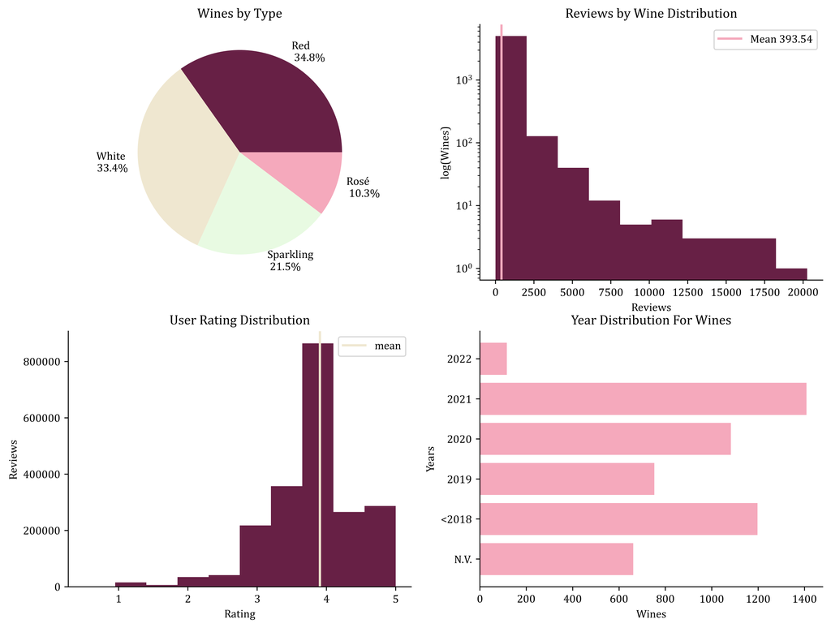

```python
import matplotlib.pyplot as plt
import matplotlib as mpl

## Stat generation
STAT = df_w[["Wine ID","Year"]].copy()
def Yearz(YEAR):
    if YEAR == "N.V.":
        return "N.V."
    elif int(YEAR) <= 2018:
        return "2018"
    elif int(YEAR) == 2019:
        return "2019"
    elif int(YEAR) == 2020:
        return "2020"
    elif int(YEAR) == 2021:
        return "2021"
    elif int(YEAR) == 2022:
        return "2022"
    else:
        return "REST"
STAT["Year_div"] = STAT.apply(lambda x: Yearz(x["Year"]),axis=1)
YDS = STAT.groupby("Year_div",as_index=False).size()
#YDS = YDS.sort_values("Year_div")

#Some stuff for plots
mpl.rcParams['font.size'] = 10.0
mpl.rcParams['font.sans-serif'] = "Cambria"
plt.rcParams['figure.dpi'] = 500
colors = ['#672045', '#efe7d0','#e8fae2', '#F5A9BC']

#Setting the plots#
fig, axs = plt.subplots(nrows=2, ncols=2, figsize=(12, 9))

#Plots
#Type of wines (Pie chart)
types = (df_w['Type'].value_counts(normalize=True) * 100).round(1)
labels = f'Red \n {types[1]}%' , f'White \n {types[2]}%', f'Sparkling \n {types[3]}%', f'Rosé \n {types[4]}%'
sizes = [types[1], types[2], types[3], types[4]]
axs[0,0].pie(sizes, labels=labels,colors=colors)
axs[0, 0].set_title("Wines by Type")


#Reviews [0,1] (Histogram)
axs[0, 1].hist(df_w["review_count"].to_list(), log=True,bins=10,color='#672045')
mean = round(df_w["review_count"].mean(),2)
axs[0, 1].axvline(mean,color='#F5A9BC',linewidth=2,label=f"Mean {mean}")
axs[0, 1].legend()
axs[0, 1].set_title("Reviews by Wine Distribution")
axs[0, 1].set_ylabel("log(Wines)")
axs[0, 1].set_xlabel("Reviews")
axs[0, 1].spines['right'].set_visible(False)
axs[0, 1].spines['top'].set_visible(False)


#Year [1,0]
YEARS = [661,1197]+[key for key in YDS["size"] if key not in [661,1197]]
LABELS = ["N.V.","<2018"]+[key for key in YDS["Year_div"] if key not in ["2018","N.V."]]
axs[1,1].barh(LABELS,YEARS, align='center',color =colors[3])
axs[1, 1].set_title("Year Distribution For Wines")
axs[1, 1].set_ylabel("Years")
axs[1, 1].set_xlabel("Wines")
axs[1, 1].spines['right'].set_visible(False)
axs[1, 1].spines['top'].set_visible(False)

#Ratings [1,1] (Histogram)
axs[1, 0].hist(df_r["User Rating"].to_list(), log=False,bins=10,color=colors[0])
axs[1, 0].axvline(df_r["User Rating"].mean(),color=colors[1],linewidth=2,label="mean")
axs[1, 0].legend()
axs[1, 0].set_title("User Rating Distribution")
axs[1, 0].set_ylabel("Reviews")
axs[1, 0].set_xlabel("Rating")
axs[1, 0].spines['right'].set_visible(False)
axs[1, 0].spines['top'].set_visible(False)


plt.show()
```

```python
import matplotlib.font_manager as fm

# Get a list of all the available fonts
fonts = [f.name for f in fm.fontManager.ttflist]

# Print the list of fonts
a = sorted(fonts)
#print(a)
```

# Network

Social Network Analysis (SNA) typically involves the collection and analysis of data related to social relationships within a particular network. The specific elements that an SNA should contain can vary depending on the goals of the analysis and the type of data being collected, but here are some common components:

### Nodes or actors

These are the individual entities that make up the network. In social networks, nodes could be people, organizations, or any other unit that can be defined as having a social relationship.

### Edges or ties

These are the connections between nodes. In social networks, edges could represent any type of social relationship, such as friendship, communication, or collaboration.

### Network structure:

This refers to the overall pattern of connections between nodes in the network. SNA often involves the analysis of the overall structure of the network, including measures such as density, centrality, and clustering.

**Modality and assortativity** are both measures that are commonly used in social network analysis, and they belong to the category of network structure measures.

**Modality** refers to the degree of clustering or groupings in a network. It is a measure of the number of distinct groups or clusters of nodes that are present in the network, and it can be used to assess the level of homogeneity or heterogeneity within a network.

**Homogeneity and heterogeneity** refer to the degree to which the nodes within a network are similar or dissimilar to each other.

Homogeneity within a network means that the nodes are more similar to each other in terms of some characteristic or attribute. For example, a social network in which all of the nodes are of the same age, gender, or occupation would be considered highly homogeneous.

In contrast, heterogeneity within a network means that the nodes are more diverse in terms of some characteristic or attribute. For example, a social network in which the nodes represent individuals from a variety of different ages, genders, or occupations would be considered highly heterogeneous.

The degree of homogeneity or heterogeneity within a network can have important implications for the overall structure and dynamics of the network. For example, highly homogeneous networks may be more prone to groupthink and conformity, while highly heterogeneous networks may be more innovative and adaptive to change. Social network analysis often involves measuring the level of homogeneity or heterogeneity within a network to better understand its characteristics and potential effects.

**In the context of a network of wine reviews**  
Modality would refer to the number of distinct groups or clusters of users who share a common pattern of wine reviews. This can provide insight into the level of homogeneity or heterogeneity within the network, as well as the overall structure of the network.

For example, if the network exhibits low modality, this would suggest that there are relatively few distinct clusters or groups of users who share a common pattern of wine reviews. This could indicate that the network is highly heterogeneous, with users from a variety of different backgrounds and with different preferences.

In contrast, if the network exhibits high modality, this would suggest that there are multiple distinct clusters or groups of users who share a common pattern of wine reviews. This could indicate that the network is more homogeneous, with users who have similar tastes or preferences for certain types of wines.

Overall, modality can provide insight into the level of clustering or groupings within the network, which can help to identify patterns of behavior and interaction among users. This information can be useful for understanding the overall structure and dynamics of the wine review network, as well as for identifying opportunities for targeted interventions or outreach efforts.

Yes, in the case of a network of wine reviews where each node represents a user with an attribute of how many reviews they have written, the pattern that modality would detect would be related to the number of wine reviews that users have written.

Modality would help identify groups or clusters of users who share a common pattern of behavior related to their level of activity within the wine review network. For example, modality might reveal clusters of users who have written a large number of reviews, clusters of users who have written a moderate number of reviews, and clusters of users who have written only a few reviews.

By identifying these patterns of behavior, modality can provide insights into the overall structure and dynamics of the wine review network. For example, it might reveal that certain groups of highly active users are more influential in shaping the overall conversation around wine reviews, or that users who have written only a few reviews are less engaged with the network and might require additional outreach efforts to increase their participation.

Overall, modality can provide important information for understanding the patterns of behavior and interaction within a network of wine reviews, and can help to guide targeted interventions and outreach efforts to improve the effectiveness of the network.

**Assortativity**, on the other hand, refers to the tendency for nodes in a network to be connected to other nodes that are similar to them in some way. For example, in a social network, assortativity might refer to the tendency for individuals with similar attributes (such as age, gender, or education level) to be more likely to be connected to each other.

Both modality and assortativity are useful measures for understanding the overall structure of a network, and can provide insights into the patterns of interaction and communication that occur within the network.

*Attributes*: These are additional characteristics of nodes or edges that can be used to understand the network better. For example, in a social network, attributes might include demographic information about individuals, such as age, gender, or occupation.

*Visualization*: SNA often involves the use of visual representations of the network structure to help analysts and stakeholders better understand the relationships between nodes. These can include graphs, diagrams, or other visualizations.

Overall, an SNA should contain data that allows for the analysis of social relationships within a particular network, including information about the nodes, edges, network structure, and any relevant attributes or context.

```python
df_u["reviews"] = df_r.groupby("User ID").agg({'Note': list}).reset_index()["Note"]
df_u
```

|  | User ID | Wine ID | User Rating | Price | Total User Purchases | followers_count | followings_count | is_featured | likes_count | comments_count | reviews | n_reviews | pref_country |
| --- | --- | --- | --- | --- | --- | --- | --- | --- | --- | --- | --- | --- | --- |
| 0 | 12 | [59894, 1141069] | 5.0 | 30.739970 | 0.0 | 6.0 | 8.0 | 0.0 | 0.5 | 0.000000 | [Vibrating fresh and citrus acidity hits you f... | 2 | 2+ |
| 1 | 58 | [1136950] | 5.0 | 254.376604 | 0.0 | 7.0 | 0.0 | 0.0 | 0.0 | 0.000000 | [\n] | 1 | france |
| 2 | 66 | [2162, 1658499, 1601135, 1268655, 1873] | 3.8 | 14.976674 | 68.0 | 2.0 | 5.0 | 0.0 | 0.6 | 0.600000 | [Nice, knh, A nice one!!!, An amazing wine, Fmg] | 5 | argentina |
| 3 | 97 | [1614431, 1624286, 1084272, 1981459, 9872, 117... | 4.0 | 31.323671 | 8.0 | 100.0 | 113.0 | 0.0 | 0.5 | 0.166667 | [Very fruity in the nose, Very fresh and fruit... | 18 | france |
| 4 | 107 | [1394024, 13145] | 3.5 | 14.393420 | 0.0 | 41.0 | 45.0 | 0.0 | 0.0 | 0.000000 | [Too light and fruity, Lovely] | 2 | 2+ |
| ... | ... | ... | ... | ... | ... | ... | ... | ... | ... | ... | ... | ... | ... |
| 766612 | 63516570 | [1084275] | 3.0 | 17.316402 | 0.0 | 0.0 | 1.0 | 0.0 | 0.0 | 0.000000 | [Solid table wine- no fuss, light and sweet ] | 1 | united-states |
| 766613 | 63516648 | [1084275] | 3.8 | 17.316402 | 0.0 | 1.0 | 3.0 | 0.0 | 0.0 | 0.000000 | [my go to in college, a nice beginner wine i r... | 1 | united-states |
| 766614 | 63516768 | [6196] | 3.8 | 13.289332 | 0.0 | 0.0 | 0.0 | 0.0 | 0.0 | 0.000000 | [Simple easy Chianti] | 1 | italy |
| 766615 | 63524772 | [981448] | 3.0 | 14.759212 | 0.0 | 3.0 | 3.0 | 0.0 | 0.0 | 0.000000 | [Good taste but very high in Tannins for my li... | 1 | france |
| 766616 | 63647513 | [1700079, 1122092] | 4.0 | 44.652826 | 0.0 | 0.0 | 0.0 | 0.0 | 0.0 | 0.000000 | [Eccellente prosecco , Lasciamo stare... Un fu... | 2 | 2+ |

766617 rows × 13 columns

```python
## User df

#List of wines reviewed and how many
df_u = df_r.groupby("User ID",as_index=False).mean()
df_u["Wine ID"] = df_r.groupby("User ID").agg({'Wine ID': list}).reset_index()["Wine ID"].to_list()
df_u["reviews"] = df_r.groupby("User ID").agg({'Token': list}).reset_index()["Token"]
df_u["n_reviews"] = df_u.apply(lambda x: len(x["Wine ID"]),axis=1)

#Which country do they prefer wines from?
df_indexed = df_w.set_index("Wine ID")
dict_w2c = df_indexed["Country"].to_dict()

def prefcountry2(INP):
    #Create dictionary from input
    stats = {}
    for ID in INP:
        #Count occurences of each country
        if dict_w2c[ID] in stats:
            stats[dict_w2c[ID]] += 1
        else:
            stats[dict_w2c[ID]] = 1
    #Sort
    stats = dict(sorted(stats.items(), key=lambda item: item[1], reverse=True))
    keys = list(stats.keys())

    #If there is on
    if len(keys) > 1:
        if stats[keys[0]] > stats[keys[1]]:
            return(keys[0])
        else:
            return("2+")
    else:
        return(keys[0])

df_u["pref_country"] = df_u.apply(lambda x: prefcountry2(x["Wine ID"]),axis=1)
```

```python
df_u
```

|  | User ID | Wine ID | User Rating | Price | Total User Purchases | followers_count | followings_count | is_featured | likes_count | comments_count | reviews | n_reviews | pref_country |
| --- | --- | --- | --- | --- | --- | --- | --- | --- | --- | --- | --- | --- | --- |
| 0 | 12 | [59894, 1141069] | 5.0 | 30.739970 | 0.0 | 6.0 | 8.0 | 0.0 | 0.5 | 0.000000 | [vibrating fresh citrus acidity hits first lig... | 2 | 2+ |
| 1 | 58 | [1136950] | 5.0 | 254.376604 | 0.0 | 7.0 | 0.0 | 0.0 | 0.0 | 0.000000 | [nan] | 1 | france |
| 2 | 66 | [2162, 1658499, 1601135, 1268655, 1873] | 3.8 | 14.976674 | 68.0 | 2.0 | 5.0 | 0.0 | 0.6 | 0.600000 | [nice, knh, nice one, amazing wine, fmg] | 5 | argentina |
| 3 | 97 | [1614431, 1624286, 1084272, 1981459, 9872, 117... | 4.0 | 31.323671 | 8.0 | 100.0 | 113.0 | 0.0 | 0.5 | 0.166667 | [fruity nose, fresh fruity, crispy fruity fres... | 18 | france |
| 4 | 107 | [1394024, 13145] | 3.5 | 14.393420 | 0.0 | 41.0 | 45.0 | 0.0 | 0.0 | 0.000000 | [light fruity, lovely] | 2 | 2+ |
| ... | ... | ... | ... | ... | ... | ... | ... | ... | ... | ... | ... | ... | ... |
| 766612 | 63516570 | [1084275] | 3.0 | 17.316402 | 0.0 | 0.0 | 1.0 | 0.0 | 0.0 | 0.000000 | [solid table wine- fuss light sweet] | 1 | united-states |
| 766613 | 63516648 | [1084275] | 3.8 | 17.316402 | 0.0 | 1.0 | 3.0 | 0.0 | 0.0 | 0.000000 | [go college nice beginner wine reckon] | 1 | united-states |
| 766614 | 63516768 | [6196] | 3.8 | 13.289332 | 0.0 | 0.0 | 0.0 | 0.0 | 0.0 | 0.000000 | [simple easy chianti] | 1 | italy |
| 766615 | 63524772 | [981448] | 3.0 | 14.759212 | 0.0 | 3.0 | 3.0 | 0.0 | 0.0 | 0.000000 | [good taste high tannins liking would try food... | 1 | france |
| 766616 | 63647513 | [1700079, 1122092] | 4.0 | 44.652826 | 0.0 | 0.0 | 0.0 | 0.0 | 0.0 | 0.000000 | [eccellente prosecco, lasciamo stare ... un fu... | 2 | 2+ |

766617 rows × 13 columns

```python
df_u.to_csv("DF_USER_3.csv",index=False)
```

```python
for TEXT in df_r["Token"]:
    if "instagram" in str(TEXT):
        print(TEXT + "\n NY TEXT \n")
```

[output not shown]

[output cut: 373 more lines]

[output not shown]